# micro612.1_assignment

Sarah S. Bassiouni

March 18, 2016

> *Directions: Your assignment is to create an html document where you analyze the gap minder data to answer a specific question you had about the data. The document should include a paragraph with R code embedded in the paragraph and the document should also include a figure that fits with the question you were interested in. You should upload the Rmd, html, and any other files to your github account. When it is complete, please send me an email with a link to your repository. This will be due March 18th.*

## Assignment for Micrbiol 612.1, Winter 2016

For this assignment, I wanted to answer the specific question, “using the gapminder dataset, how has life expectancy changed over time, from 1952 to 2007, in each of the continents?”

To do so, I plotted life expectancy over time for each continent on the same graph (Figure 1). Continents were uniquely colored to visually distinguish. Using geom_smooth, I plotted a regression line for each continent; this essentially resulted in a summary of the life expectancy for that continent.

```
## [1] "integer"
```

```
## [1] "country"   "year"      "pop"       "continent" "lifeExp"   "gdpPercap"
```

```
## 'data.frame':    1704 obs. of  6 variables:
##  $ country  : Factor w/ 142 levels "Afghanistan",..: 1 1 1 1 1 1 1 1 1 1 ...
##  $ year     : int  1952 1957 1962 1967 1972 1977 1982 1987 1992 1997 ...
##  $ pop      : num  8425333 9240934 10267083 11537966 13079460 ...
##  $ continent: Factor w/ 5 levels "Africa","Americas",..: 3 3 3 3 3 3 3 3 3 3 ...
##  $ lifeExp  : num  28.8 30.3 32 34 36.1 ...
##  $ gdpPercap: num  779 821 853 836 740 ...
```

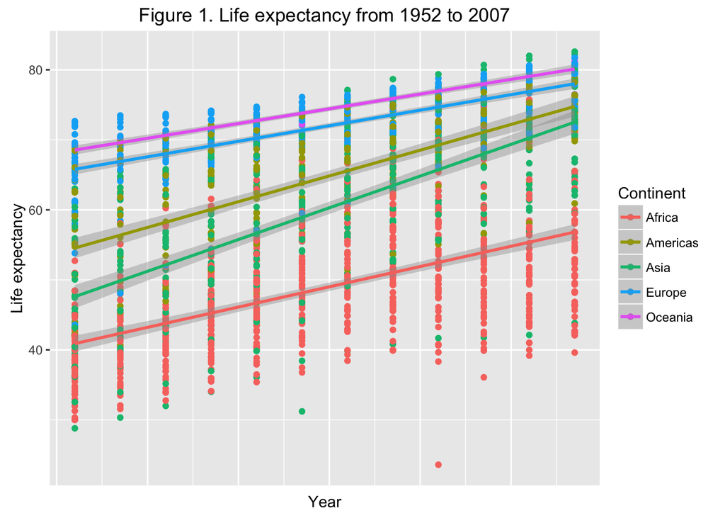